618,316 sighting reports · 1800 to 2026 · seven prompts · one AI

# Do UFOs follow the *news cycle*?

We took 618,316 UFO reports and tested what actually moves them: fireworks, satellites, hearings, movies, and plain old human nerve. Written for skeptics and believers at the same table.

Short attention span? Jump to the TL;DR ↓

One human directing, one AI building. Receipts in How it was made.

**618,316**deduplicated reports

**2**independent databases

**r = 0.999**data validation

**384**Starlink launches

**14**attacks answered

**21**numbers machine-checked

01

## The point: nobody's ever checked the boring stuff at this scale

This project never asks what people saw. It asks a question data can actually answer: **why do people report?**

A UFO report is a human decision. Someone saw something, sat with it (sometimes for 30 years), and one day typed it into a form. The news, the movies, the neighbors, the embarrassment: all of it shapes that decision. So a UFO database is secretly one of the best behavioral datasets on Earth. 618,316 rows of attention, fear, and nerve.

Plain English

Picture a sky that never changes. Reports would still spike on July 4, jump after a hearing, and surge when SpaceX launches. Before anyone can claim something weird is up there, you have to measure all that human noise first. We did. What's left after the noise is the good part, for both camps.

One promise, kept the whole way: nothing here calls any witness a liar, and nothing here confirms a single craft. Skeptics get receipts. Believers get an honest count of what the boring explanations can and can't absorb. Everyone gets the same numbers.

### The four bets we made before running anything

#### Bet 1: Reports follow the news

Big UAP moments should spike reports within days.

**Result:** real objects in the sky spike reports 2.2x. Hearings don't create new sightings at all. They make people finally report old ones, at 2x. Half right, in the most interesting way possible.

SPLIT

#### Bet 2: People, not portals

State report counts should track population, not famous "hotspots."

**Result:** population explains 88% of which states report. The leftovers are dark skies and Roswell tourism, not mystery.

WON

#### Bet 3: Military misidentification

Reports should cluster near military airfields.

**Result:** they do, 1.39x more than population predicts. But civilian airports score 1.57x. It's an aviation story, not a secret base story.

SPLIT

#### Bet 4: The trend is plumbing

Long-run rises and falls should track reporting technology, not the sky.

**Result:** web forms up, old archives dead, Reddit up 1000x. The famous "2024 decline" was two databases going stale.

WON

· · 🛸 · ·

02

## The data, and why you can trust it

618,316 deduplicated reports from six databases (NUFORC, MUFON, UFOCAT, UPDB, UFO-search, r/UFOs), merged by the open source UFOSINT project. We audited it before drawing a single conclusion.

**Pin it**The official download link was broken. We pinned one exact snapshot and verify its checksum on every run. Every number here is reproducible forever.

**Audit it**Profiling found three separate date fields per report (when it happened, when it was filed, when it was posted). That accident of schema powers the best finding on this page.

**Respect the seams**The six sources collect in different eras. Only NUFORC and MUFON run continuously, so they became two independent panels. Nothing counts as a finding unless both agree.

**Clean it**Every record accounted for: 97.2% carry plausible dates, and 118,519 records got their US state back through point-in-polygon geometry.

**Enrich it**Census population and boundaries, a 28-event media calendar, 194 military installations picked blind to UFO lore, 95 airports, 384 Starlink launches.

Bug caught

The audit caught the traps early: 1.85% duplicate overlap between NUFORC and MUFON (so we never pool them for stats), backfilled old MUFON records (so its panel starts in 2006), and a pileup of reports dated "the 1st of the month" from people typing *June 1997* as *06/01/1997*. Remember that last one. It comes back later disguised as a mystery.

And because "some database from GitHub" deserves suspicion, we checked our copy against a completely independent public scrape of NUFORC:

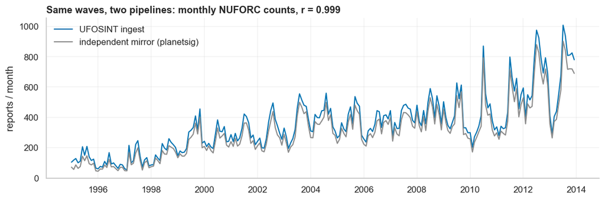

**Same waves, two pipelines.** Monthly counts in our database vs an independently scraped mirror: correlation r = 0.999. The foundation holds.

03

## Two centuries of reports, six charts, zero mysteries needed

Every chart below changed how we built the analysis. None of them needed aliens.

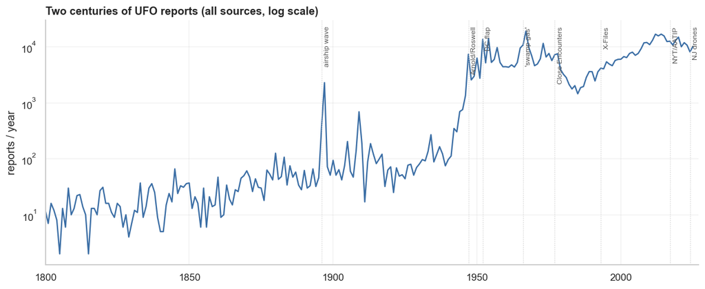

**Two centuries of reports.** See the spike at 1896? Newspapers invented a "mystery airship" craze and thousands reported it. Media was manufacturing sighting waves 60 years before anyone said "flying saucer."

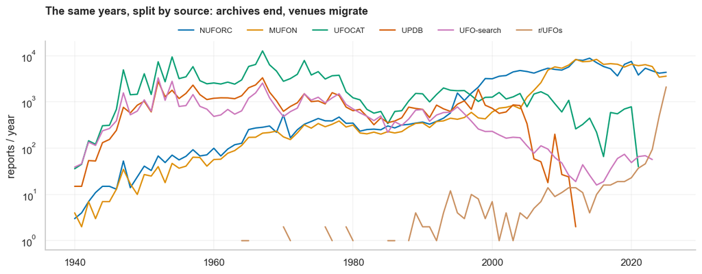

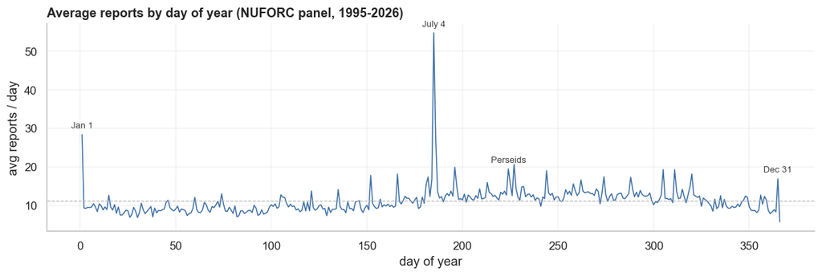

**The calendar owns the sky.** July 4 runs about 5x a normal day. Fireworks, lanterns, and a whole country looking up. The August bump is the Perseid meteor shower.

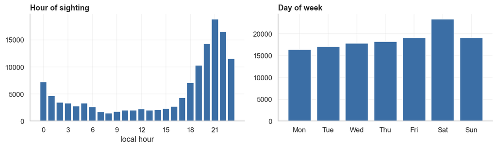

**9 to 11 pm. Saturdays. Summer.** The sky doesn't know what a Saturday is. People do. That one sentence is most of this project.

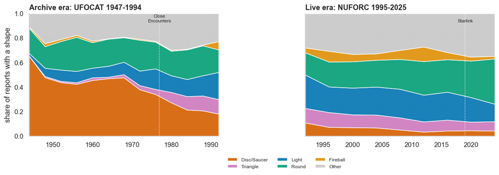

**Shape fashion.** Saucers fall from 65% of reports to 7%. Triangles surge in the X-Files 90s. The phone era belongs to lights and orbs. People report what the culture shows them.

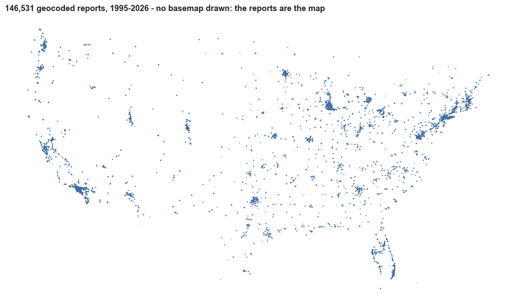

**No map was drawn here.** 146,531 reports plotted raw, and there's the country: cities, interstates, the empty Plains. Reports go where people are. Every geography claim has to beat that fact first.

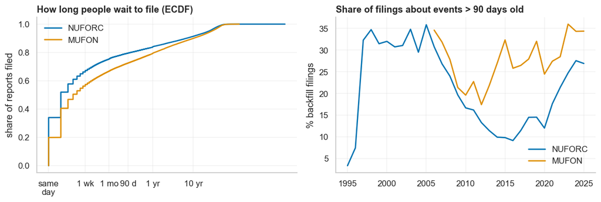

**When people file.** Most reports arrive within a week. But 15 to 25% describe events more than a year old. Sometimes decades. Someone carries a memory for 30 years, then one week decides to type it in. What happens that week? Keep reading.

04

## The model: a weather forecast for UFO reports

One honest statistical model, stress-tested against a fancy machine-learning challenger. The boring one won, and we can prove it.

Plain English

The model learns what a normal Tuesday in March should produce, given the season, the weekday, and the holidays. After a big event we ask: did the next days beat the forecast? Then the acid test: would 2,000 random fake event dates have "beaten" it too? If fake dates work as well as real ones, there's no effect.

#### Counts get a count model

Daily report counts are jumpy integers. Variance runs 9x the mean. The negative binomial model prices that wildness in. Simpler models pretend it away.

CHOSEN BY THE DATA

#### All events at once

All 18 events get before and after windows, fitted together, so overlapping events compete instead of double-counting. The "before" windows catch hype that starts early.

NO DOUBLE COUNTING

#### Fake dates as the referee

Every effect gets ranked against thousands of placebo dates, with a correction for testing many events. Cheap, brutal, hard to fool.

PLACEBO-FIRST

#### Two databases must agree

NUFORC and MUFON are run by different people with different systems. A result that shows in only one isn't a result.

REPLICATION RULE

Bug caught, in the easy alternative

We refit the headline model with plain Poisson, the lazy default. Its confidence interval: [2.02, 2.28]. The honest one: [1.39, 3.55]. The lazy model is **7.7x too confident**. Run this data through Poisson and you'd "discover" significant effects everywhere. Skeptics, aim your fire at anyone's UFO stats that don't handle this.

### We gave machine learning its shot too

A tuned gradient-boosted model got new features (moon phase, eight meteor showers, days since the last Starlink launch) and a training set through 2022. Then it faced 2023 to 2026, unseen. It lost to the plain seasonal model. A hybrid tied it. Here's the punchline: random day-to-day noise caps any model's daily accuracy at a correlation of 0.43, and the calendar alone already gets you 41% of the way there. There's almost nothing left for the machine to find.

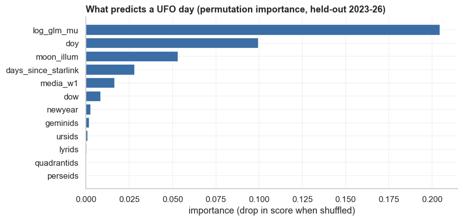

**What predicts a UFO day** (on data the model never saw): the season, the calendar, the Moon (full moon means about 4% fewer reports, moonlight washes out the sky), the Starlink schedule, and media windows. Nothing alien-shaped survives.

**The full specification, for the stats people**

Negative binomial GLM, log link. Dispersion by Cameron-Trivedi auxiliary regression (alpha 0.25 NUFORC, 0.13 MUFON). Day-of-week dummies, three Fourier harmonics of day of year, year fixed effects, holiday and meteor-shower dummies. Per event: pre [-14,-1], [0,7], [8,30] indicators fitted jointly. Newey-West HAC(14) errors, insensitive to lag 7 or 28. Primary inference: 2,000-draw placebo ranking at 7 and 30 day horizons, Benjamini-Hochberg FDR. Era-matched placebo pools as robustness. Category pooling for power. Leave-one-out stability. Minimum detectable effects reported for null results. One notebook, one command.

· · 👽 · ·

05

## Congress can't make you see a UFO. It can make you finally admit you saw one.

Pool the events by type and ask the real question: what actually moves reports?

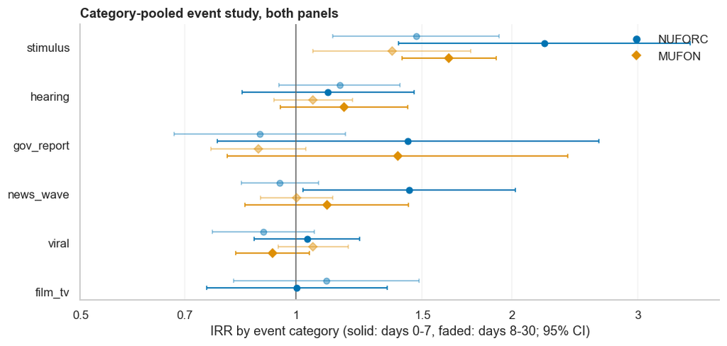

**The scoreboard, both databases.** One category clears the bar in both systems: real things verifiably in the sky (a missile test, a spy balloon, a drone wave, a satellite train). Those run **2.22x** in NUFORC and **1.64x** in MUFON the week after. Hearings? **1.11x**. Statistically nothing.

Plain English

When something real flies over, reports jump in both databases, every way we slice it. When Congress holds a UAP hearing, new sightings don't budge. And it's not a power problem: anything bigger than a 1.48x hearing effect is ruled out by the data.

But remember the three date fields. The data tracks when sightings happened, when they were filed, and which filings describe old events. Switch from the "happened" clock to the "filed" clock and the hearings light up:

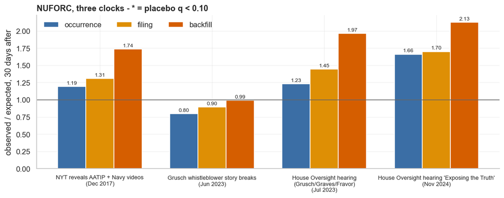

**The three clocks.** After every big attention moment the pattern repeats: new sightings barely move, filings move more, and **filings about years-old sightings move most**, roughly 2x after each major hearing. The week after the 2017 New York Times story, someone filed a sighting from **120 years earlier**.

Why this matters

Hearings don't change the sky. They change the embarrassment math. Attention works like an amnesty: it makes reporting feel safe, and people come forward with what they've been sitting on for decades. That's a finding about stigma. It doesn't debunk a single witness, and it doesn't confirm a single craft. Both camps get to keep it.

Three deadpan footnotes. The hyped 2021 ODNI report is the only event that **lowered** reports (0.6x, the week after its official shrug). Modern movies do nothing (*Independence Day*: 0.70x). And Storm Area 51, two million RSVPs and all, produced statistical silence.

06

## SpaceX accidentally ran the biggest UFO experiment in history

384 launches on a public schedule. Each one is a test nobody signed up for.

A fresh batch of Starlink satellites crosses the night sky as a bright string of pearls for a few nights after launch. Launch dates are public and set by orbital mechanics, not UFO culture. So here's the test: if misidentification drives reports, "Formation" shaped reports should jump for 0 to 3 nights after each launch. Shapes a satellite train can't imitate (a triangle, a disc) shouldn't move at all.

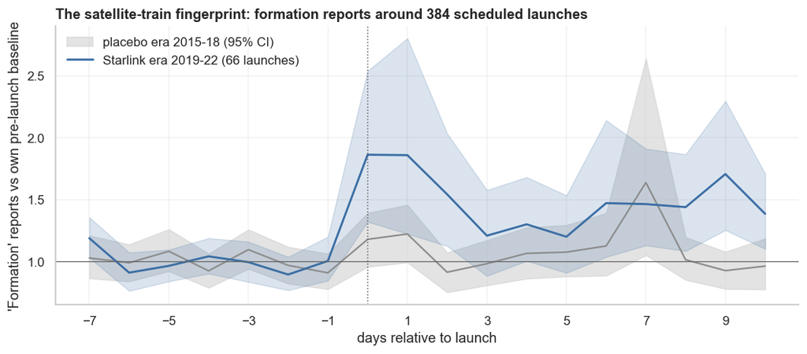

**The satellite-train fingerprint.** Flat before launch (nothing to see yet). Jump on nights 0 to 3. Decay as the train spreads out. The same calendar windows in the years before Starlink existed: nothing.

Technical note

Formation reports: **1.70x** [1.26, 2.30] in launch windows. Triangle control: 1.00. Pre-Starlink placebo years: 0.96. The formation-vs-triangle difference-in-differences, the estimate weather or hype can't fake: **1.45x** [1.04, 2.02]. About **1 in 10** of every formation-shaped UFO report in the era sits inside SpaceX's published schedule.

Plain English

The sky learned a new trick in 2019. Exactly one column of the database responded, exactly on schedule, and never before the launch. It's the cleanest result in the whole project because the experiment repeats 66 times with a control group.

07

## The 20 strangest days in 30 years, named one by one

Flip the whole project around. Let the model pick the days it can't explain. Then hunt down every single one.

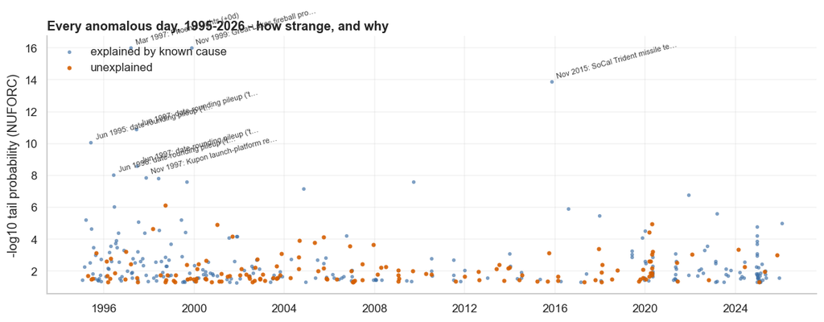

[output not shown]

### #1 on the board: the Phoenix Lights

March 13, 1997. Two events in one Arizona evening. Around 8 pm, a silent V of lights crossed a 300-mile corridor from Nevada through Phoenix to Tucson. Around 10 pm, a row of bright lights hung over the city. Thousands watched. Wikipedia calls it [perhaps the most widely witnessed UFO event in history](https://en.wikipedia.org/wiki/Phoenix_Lights).

The official accounting: the 10 pm lights were LUU-2 illumination flares dropped by Maryland Air National Guard A-10s over the Barry M. Goldwater Range. The 8 pm V matched five A-10s flying in formation with steady lights. Plenty of witnesses never accepted the aircraft answer, and the case has the best character arc in UFO history: Governor Fife Symington mocked it in 1997 with an aide in an alien costume, then said in 2007 that he saw the V himself and called it "bigger than anything that I've ever seen."

What our data adds: that one night, NUFORC logged 84 reports against 3 expected, past 1-in-a-trillion under the model's null, and the week after ran 5.4x (placebo q = 0.009). The strongest single event in the entire study. It sits on the "named" list because real things were verifiably in the sky that night: flares and aircraft. Whether the 8 pm V was only aircraft is an argument about testimony, and counts can't settle testimony. Which is exactly where this project draws its line.

Plain English

The strangest days on record turn out to be rockets, fireworks, and paperwork. Plus one orphan night. Skeptics get names and dates. Believers get something rarer: a certified, model-audited shortlist. One night in 30 years beats arguing about 618,316 rows.

08

## Where UFOs live: dark skies, Roswell, and airports

Population explains 88% of which states report. The leftovers have addresses.

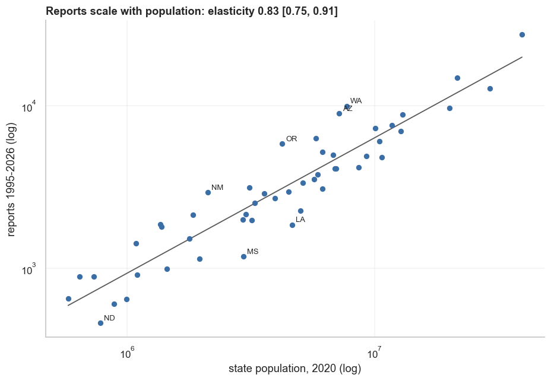

**People in, reports out.** Each dot is a state. More people, more reports, almost one for one (elasticity 0.83). The states floating above the line are the interesting ones.

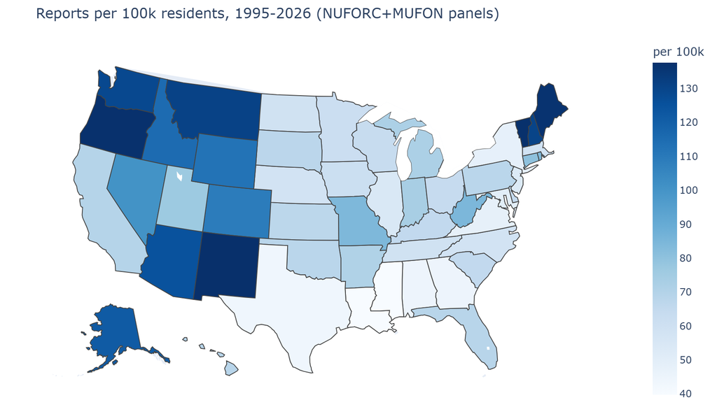

**Reports per 100,000 residents.** The per-capita leaders are dark-sky, outdoorsy states: Washington, Montana, Vermont, Maine, Alaska. And New Mexico.

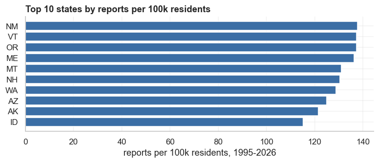

**Top 10 per capita.** New Mexico is number one. Mystical? We checked: reports are **2.08x** over-represented within 60 km of Roswell compared to where New Mexicans live. Lore is a real economic force, and it shows up in the data like one.

### And yes, cow country shows up

Now the loaded question. Do reports cluster near military bases?

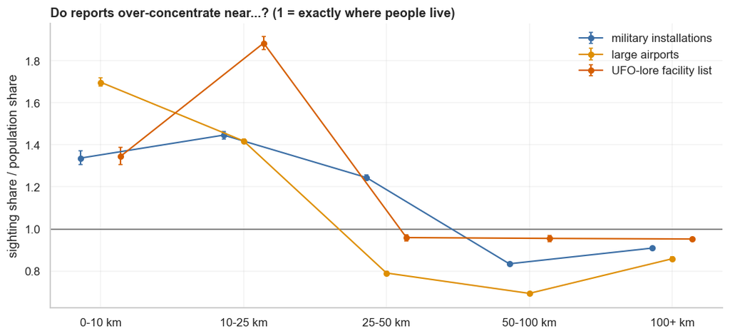

**The military question, with a control group.** Reports near 194 military installations (picked by DoD data, blind to UFO lore): 1.34x what population predicts. Near 95 large civilian airports: 1.70x. And the database's own "famous UFO sites" list peaks at 1.88x, which is what selection bias looks like: places famous because of sightings score highest near those sightings.

Technical note

Under the strictest symmetric treatment (drop the biggest metro pileups from both lists), it's **1.57x airports vs 1.39x bases**. Same order, narrower gap, non-overlapping intervals. If proximity to civilian aviation predicts reports at least as well as proximity to Area 51's mythology, the simple reading is misidentified aircraft, not leaked secrets.

09

## The "New Jersey" drone wave was 83% not from New Jersey

Winter 2024. The biggest UFO story in a decade. The reports know something the headlines didn't.

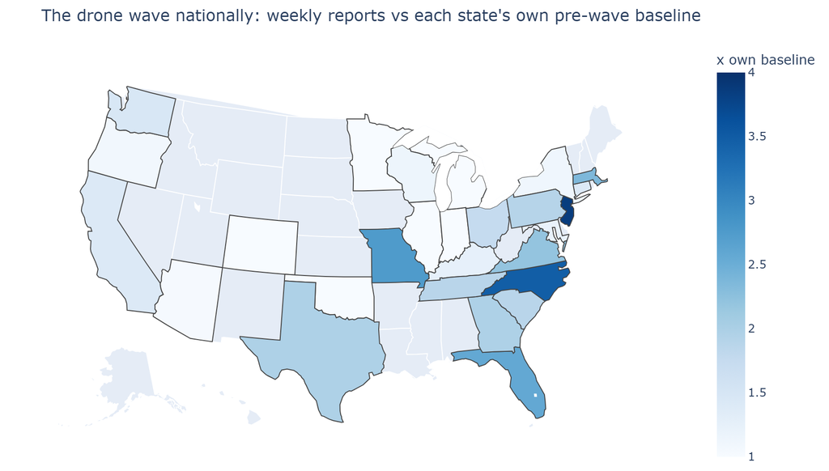

**The wave, state by state,** each measured against its own normal. New Jersey peaked at 4x itself. Twelve states coast to coast ran above 1.5x theirs.

Add up the national surge and **83% of it was filed outside NJ, NY, PA, and CT**. California, Florida, and Texas led the pack, with zero confirmed drone activity. The rest of the country peaked at 2.5x its own baseline on nothing but coverage. A local stimulus became a national reporting event in eight weeks. Same amnesty mechanism as the hearings, playing out on a map in fast forward.

### Drones got better. Sightings got weirder.

Rewind ten years and a drone was an expensive toy. Now the FAA has hundreds of thousands of them registered, the true fleet is larger, and every one is a silent cluster of lights that can hover, dart sideways, and park in the sky. A machine purpose-built to generate UFO reports. Our shape data catches the shift: the modern era belongs to lights, orbs, and formations, the exact profile of a quadcopter at night.

The 2024 wave shows the full loop. Some real drones over New Jersey. Then wall-to-wall coverage. Then a country full of people stepping outside, seeing ordinary aircraft and hobby drones, and filing. Better drones didn't just fill the sky. They gave every light up there a plausible new name.

10

## Then we attacked everything we just told you

#### "Your database is an unaudited hobby project."

Monthly counts match an independently scraped mirror at r = 0.999. The waves are real waves.

DEFEATED

#### "Your December hearing effect is just a meteor shower."

A hole we found in our own model: the Geminids peak sits inside one key window. Refit with all eight showers controlled. Result barely moved (1.43 to 1.45).

TESTED, SURVIVES

#### "Airports-beat-bases is a geocoding artifact."

Partly fair. City-centroid coordinates flatter airports. We reran both lists under identical rules and rewrote the claim with the narrower numbers.

CONCEDED & FIXED

#### "Your hearing null just means weak stats."

No. The data rules out any hearing effect bigger than 1.48x. An interval, not a shrug.

QUANTIFIED

#### "Your placebo dates come from quieter years."

Redrew them era-matched, within 3 years of each event. All five significant events survive.

DEFEATED

#### "You overstated your own ML result."

True. We'd written "nearly saturated" when the math says 41% of a 0.43 ceiling. The sentence got replaced. The red team applies to us too.

SELF-CORRECTED

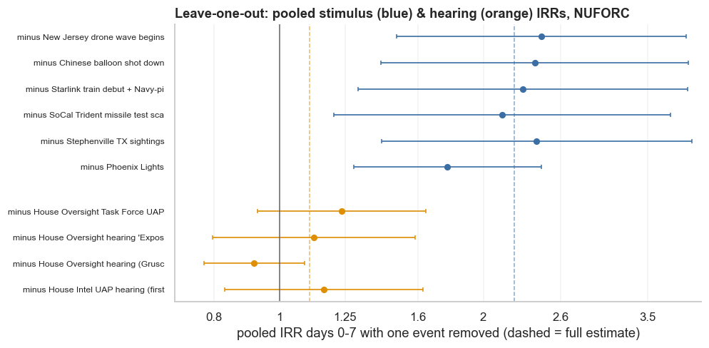

**No single event carries the result.** Drop any real-stimulus event, even Phoenix Lights, and the effect stands. Drop any hearing and the null stays null.

Why this design

The document polices itself going forward. A claims ledger at the end of the notebook recomputes all 21 headline numbers on every run and fails loudly if the text and the data drift apart. Continuous integration, but for conclusions.

11

## Seven prompts made everything here, including this page

One person with ideas and standards. One AI doing the labor. Here's the receipt, starting with the prompt that started it all:

| # | The prompt, in one line | What came out |
| --- | --- | --- |
| 1 | Build the whole project | Pinned data, cleaning pipeline, event study, geography, first findings |
| 2 | Review your own work like a senior engineer, then keep going | The audit that created the two-database replication rule, plus all the models |
| 3 | Max genius mode: find the wow | Starlink experiment, strangest-days leaderboard, the 120-year-old memory, the drone map |
| 4 | Now attack everything you found | 14 attacks, 3 amendments, the claims ledger |
| 5 | Prepare the final defense | The full Q&A dossier inside the notebook |
| 6 | Build the page that wows readers | The first version of this page |
| 7 | Now make it human | This rewrite: plain words, the TL;DR, and these receipts |

The workflow each time: plan mode first (the AI proposes, the human approves or redirects), then execute. The human's fingerprints are on every fork: which findings deserved the spotlight, when the writing sounded like a robot, and the entire idea of turning the analysis on itself.

Honest footnote: those are the seven big ones. Getting to done took a stack of small follow-up prompts on top. Fix this button. Cut that box. Double-check that 1998 date. The big prompts built the machine; the little ones are where the taste lives. And one of those little fact-checks ended up solving a 28-year-old mystery. See the end of the page.

### What did it cost?

Honest estimate

12

#### If you came in skeptical

- Report volume obeys population (0.83 elasticity), weekends, fireworks (5x), the Moon (4% fewer at full), and SpaceX's launch calendar (1.70x). Human behavior, measured.
- The 20 strangest days in 30 years reduce to rockets, fireworks, and typos, with names and dates attached.
- Hearings and headlines move filing, not seeing. The "2024 decline" and the "national drone invasion" both dissolve under honest accounting.
- A tuned ML model can't beat a plain seasonal forecast. At the daily level there's nothing hidden to find.

### Limits, stated plainly

Reports aren't objects, and reporters aren't a random sample of witnesses. Coordinates are city-level. The event calendar holds 18 modeling events, so power is honest but finite. Hearings get scheduled because attention is already rising, so post-event bumps bound the effect rather than isolate pure cause. And the "1-in-a-trillion" day scores rank days; they aren't literal betting odds.

### Run it yourself

One notebook, one command. Pinned data with checksum verification, five documented public datasets, and the claims ledger standing guard. Every number and figure on this page comes from that single reproducible run.

13

## TL;DR

We took 618,316 UFO reports and checked what really makes people report UFOs. Answer: fireworks, SpaceX, the news, and finally feeling safe enough to talk. One night in 30 years still has no explanation.

**The big picture:** yes, UFO sightings are correlated with real events in the sky. When something actually flies over (a missile test, a satellite train, a spy balloon), reports jump within days, in both databases, right on schedule. The news moves reports too, but mostly by unlocking old sightings people were sitting on. And after every known cause is subtracted, 1 day out of 11,354 still spikes with nothing to pin it on: Sep 23, 1998. It had company until we fact-checked this page. Correlated where the world supplies a cause. Unexplained where it doesn't.

- **July 4** runs 5x a normal day. Fireworks work.
- **Starlink launches** spike "formation" UFO reports 1.7x for three nights. On SpaceX's published schedule. 1 in 10 formation reports of the era sits inside it.
- **Hearings create zero new sightings** but double the reports of decades-old ones. Attention is an amnesty. One filed sighting was 120 years old.
- **Population explains 88%** of which states report. Dark skies explain most of the rest.
- **New Mexico is #1 per capita**, and its excess is 2.08x concentrated around Roswell. Tourism, in the data.
- **Airports beat military bases**, 1.57x vs 1.39x. It's an aviation story.
- **The "New Jersey" drone wave** was 83% filed from other states. Panic travels faster than drones.
- **The 20 strangest days in 30 years:** 9 named causes, 9 typos, 1 mix, 1 genuine unknown (Sep 23, 1998). The other unknown fell during fact-checking: a Russian rocket stage.
- **A tuned ML model lost** to a plain seasonal forecast on unseen years. The full moon cuts reports 4%.
- **Seven big prompts** to one AI built all of it, including this page, plus a pile of small fix-it prompts to finish, for roughly the price of a textbook. Every number is machine-verified on every run.

### Two mysteries entered this article. One survived.

Earlier drafts ended with two unexplained nights. Then a fact-check did its job. November 14, 1997 looked like this in the raw records: 38 reports in one evening, 30 from Washington state, 27 at 9 pm, shape "Formation," durations of 30 seconds to 3 minutes, seen from Oregon to British Columbia. Too long for a meteor. Too widespread for flares. That's the signature of a rocket stage breaking up on re-entry. Our launch catalog showed a Russian Proton launch two days earlier, and the satellite observers' [decay archive](https://www.satobs.org/decay.html) confirms it: the Kupon launch platform came down over the Pacific Northwest that night, and the archive even notes it "resulted in a number of UFO reports." Mystery number one: solved, 28 years later, by a follow-up prompt.

September 23, 1998 survived the same treatment. A 2-to-8-second fireball at 9:10 pm, reported independently from Seattle, Tacoma, Everett, Bothell, and Victoria BC inside the same 20 minutes, with a second cluster over Texas that evening. 43 raw reports, original timestamps intact, filed within a day or two. No holiday, no meteor-shower peak, no launch, no re-entry we can find, no news event, no data-entry artifact. The likely truth is boring: a bright bolide that fell before the internet kept records of falling things. But likely isn't named. Out of 11,354 days, this one is still open. If you want a mystery, start there.

↑ Back to the top for the full story

[Home](https://along777.github.io/along/)